# Project.2: House Prices – Advanced Regression Techniques

시각화리포팅5조(penta-core)

2022-02-24

# 1 과제 목차

- EDA와 시각화를 통해 데이터를 이해하시오.
- 다양한 선형 회귀분석 방법을 적용하시오.
- 선형 회귀모델을 피팅하시오. (step, 규제화 등)
- R markdown으로 결과 보고서를 작성하시오

# 2 분석 준비 단계

## 2.1 패키지 로딩

```r
library(dplyr)
library(corrplot)
```

## 2.2 파일불러오기

```r
df <- read.csv("train.csv", stringsAsFactors = F)

head(df,3)
```

```
##   Id MSSubClass MSZoning LotFrontage LotArea Street Alley LotShape LandContour
## 1  1         60       RL          65    8450   Pave  <NA>      Reg         Lvl
## 2  2         20       RL          80    9600   Pave  <NA>      Reg         Lvl
## 3  3         60       RL          68   11250   Pave  <NA>      IR1         Lvl
##   Utilities LotConfig LandSlope Neighborhood Condition1 Condition2 BldgType
## 1    AllPub    Inside       Gtl      CollgCr       Norm       Norm     1Fam
## 2    AllPub       FR2       Gtl      Veenker      Feedr       Norm     1Fam
## 3    AllPub    Inside       Gtl      CollgCr       Norm       Norm     1Fam
##   HouseStyle OverallQual OverallCond YearBuilt YearRemodAdd RoofStyle RoofMatl
## 1     2Story           7           5      2003         2003     Gable  CompShg
## 2     1Story           6           8      1976         1976     Gable  CompShg
## 3     2Story           7           5      2001         2002     Gable  CompShg
##   Exterior1st Exterior2nd MasVnrType MasVnrArea ExterQual ExterCond Foundation
## 1     VinylSd     VinylSd    BrkFace        196        Gd        TA      PConc
## 2     MetalSd     MetalSd       None          0        TA        TA     CBlock
```

[output cut: 33 more lines]

## 2.3 데이터 전처리

```r
df <- df[,c("LotArea", "YearBuilt", "X1stFlrSF","GarageArea","SalePrice")]
head(df,3)
```

```
##   LotArea YearBuilt X1stFlrSF GarageArea SalePrice
## 1    8450      2003       856        548    208500
## 2    9600      1976      1262        460    181500
## 3   11250      2001       920        608    223500
```

```r
df$SalePrice <- as.numeric(df$SalePrice)

table(is.na(df)) # 결측값 없음
```

```
##
## FALSE
##  7300
```

```r
dim(df)               # data 구조 확인
```

```
## [1] 1460    5
```

구조 확인 결과 5개의 변수에 1460개의 관측치가 있으며, 종속 변수는 ‘SalePrice’ 변수이다.

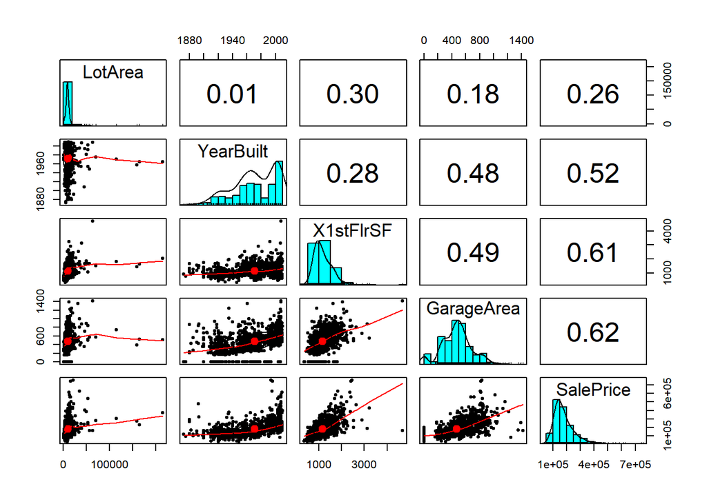

```r
par(mfrow = c(1, 1))
library(psych)
pairs.panels(df)
```

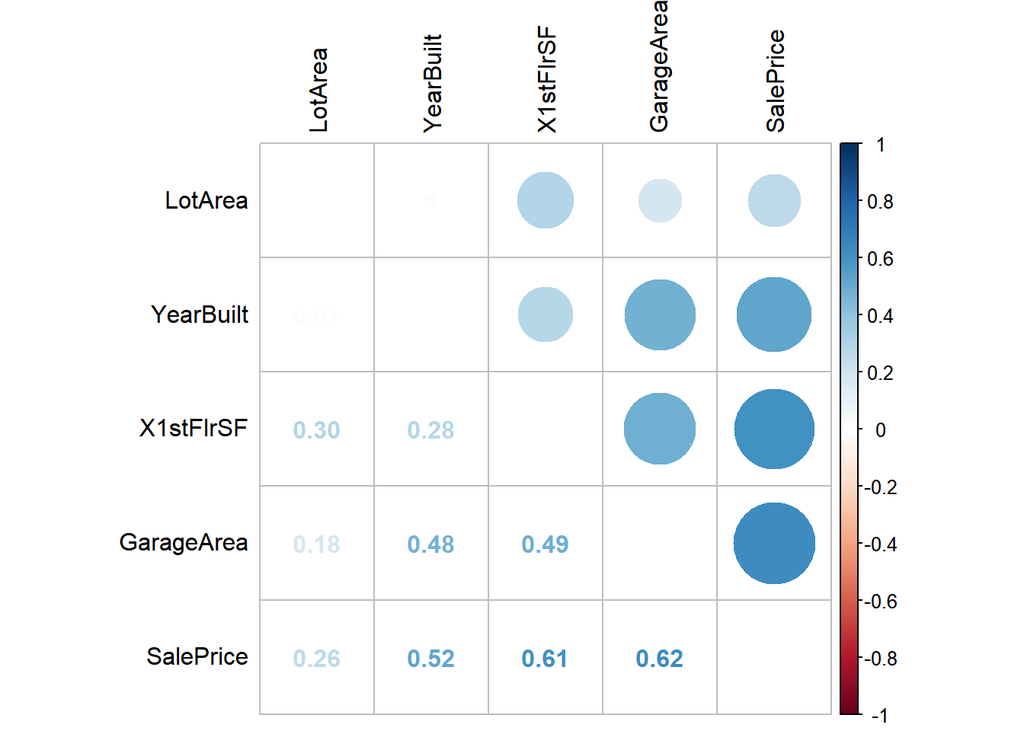

```r
##
corrplot.mixed(cor(df),
               tl.col = 'black',   # 변수명 색깔
               tl.pos = 'lt',      # 변수명 왼쪽 표시
               number.cex = 1)    # matrix안 상관계수 text 크기
```

# 3 다중회귀

```r
fit <-lm(SalePrice~., data = df)
summary(fit)
```

```
##
## Call:
## lm(formula = SalePrice ~ ., data = df)
##
## Residuals:
##     Min      1Q  Median      3Q     Max
## -449948  -29291   -5853   20399  416359
##
## Coefficients:
##               Estimate Std. Error t value Pr(>|t|)
## (Intercept) -1.411e+06  1.003e+05 -14.057  < 2e-16 ***
## LotArea      8.033e-01  1.440e-01   5.578 2.89e-08 ***
## YearBuilt    7.339e+02  5.178e+01  14.173  < 2e-16 ***
## X1stFlrSF    7.191e+01  4.188e+00  17.170  < 2e-16 ***
## GarageArea   1.115e+02  8.032e+00  13.888  < 2e-16 ***
## ---
## Signif. codes:  0 '***' 0.001 '**' 0.01 '*' 0.05 '.' 0.1 ' ' 1
##
## Residual standard error: 52060 on 1455 degrees of freedom
## Multiple R-squared:  0.5717, Adjusted R-squared:  0.5705
## F-statistic: 485.5 on 4 and 1455 DF,  p-value: < 2.2e-16
```

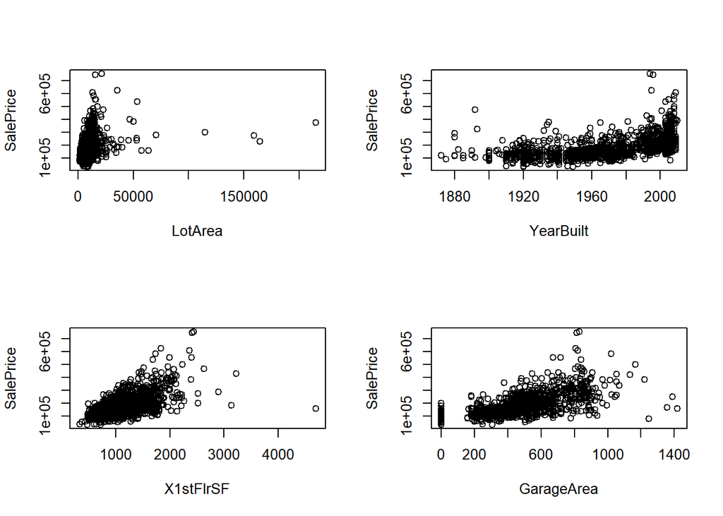

```r
par(mfrow = c(2, 2))
# y(종속변수)와 각각의 x(독립변수)에 대한 산점도
plot(SalePrice~., data =df)
```

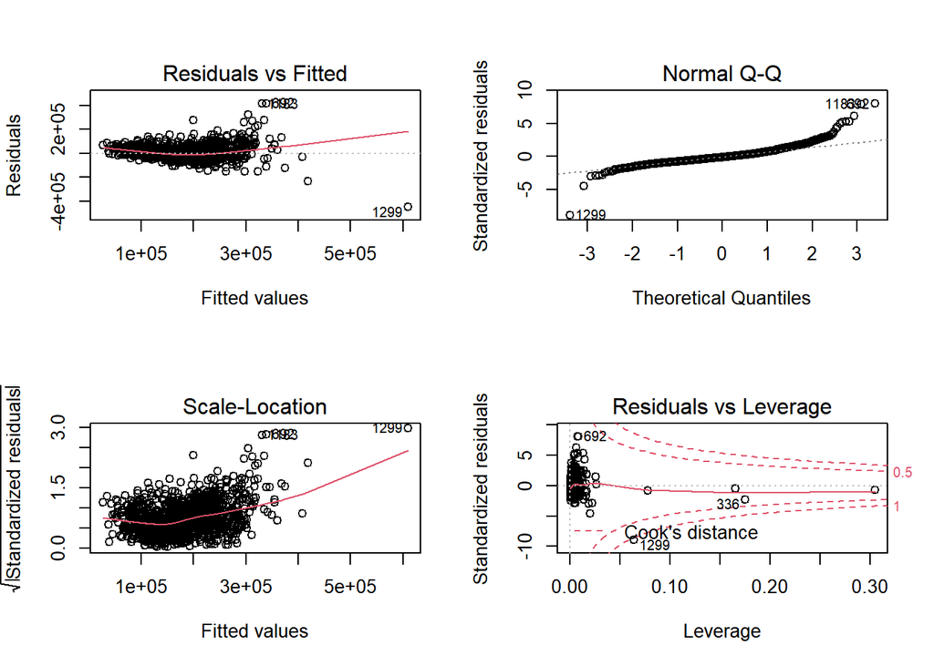

```r
# 회귀모형이 적절한가 회귀진단을 위한 plot
plot(fit)
```

```r
# 등분산성 : 빨간 실선은 잔차의 추세를 나타냄
# 빨간 실선이 점선에서 크게 벗어난다면 예측값에 따라 잔차가 크게 달라진다는 것이다.
# 정규성 : 잔차가 정규분포를 띄면 점들이 점선을 따라 배치 되어 있어야 함

summary(fit)
```

```
##
## Call:
## lm(formula = SalePrice ~ ., data = df)
##
## Residuals:
##     Min      1Q  Median      3Q     Max
## -449948  -29291   -5853   20399  416359
##
## Coefficients:
##               Estimate Std. Error t value Pr(>|t|)
## (Intercept) -1.411e+06  1.003e+05 -14.057  < 2e-16 ***
## LotArea      8.033e-01  1.440e-01   5.578 2.89e-08 ***
## YearBuilt    7.339e+02  5.178e+01  14.173  < 2e-16 ***
## X1stFlrSF    7.191e+01  4.188e+00  17.170  < 2e-16 ***
## GarageArea   1.115e+02  8.032e+00  13.888  < 2e-16 ***
## ---
## Signif. codes:  0 '***' 0.001 '**' 0.01 '*' 0.05 '.' 0.1 ' ' 1
##
## Residual standard error: 52060 on 1455 degrees of freedom
## Multiple R-squared:  0.5717, Adjusted R-squared:  0.5705
## F-statistic: 485.5 on 4 and 1455 DF,  p-value: < 2.2e-16
```

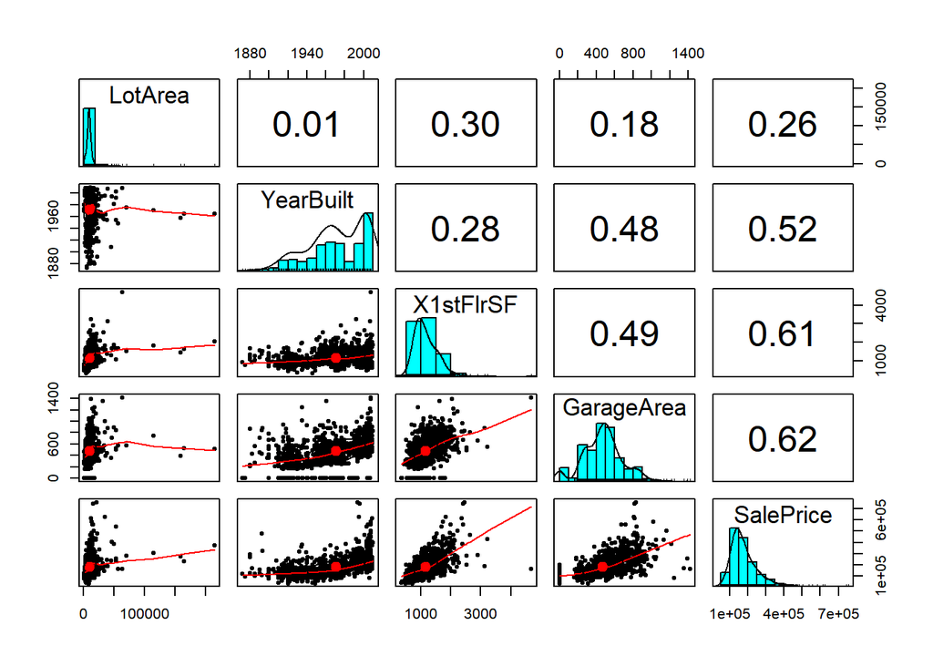

```r
# 각각의 산점도와 다중공성성
library(psych)
library(car)

# 각각 모든 변수들간 산점도 그리기

# 다중공선성 - 다중회귀분석에서 x변수(설명변수, 독립변수)들 끼리 상관관계가 존재할 경우
# 회귀 계수의 분산을 크게하여, 회귀분석 시 추정 회귀 계수를 믿을 수 없게 되는 문제.
pairs.panels(df[names(df)])
```

```r
# 위 그래프에서 숫자는 상관관계를 나타내며, -1에 가까우면 음의 상관관계, 1에 가까우면 양의 상관관계입니다.

# 다중공선성 확인
# 'sqrt(car::vif(fit))' 가 2보다 크면 다중공선성이 있는 것!!
sqrt(car::vif(fit)) > 2
```

```
##    LotArea  YearBuilt  X1stFlrSF GarageArea
##      FALSE      FALSE      FALSE      FALSE
```

```r
# 위에서는 모두 false이므로 다중공선성이 없다고 판단할 수 있음
```

이번에는 다중선형회귀분석을 할때 회귀모형에서 어떤 x변수(설명변수)를 어떻게 선택해야 하는지 설명변수가 유의하지 않다고 해서 한번에 다 제거해서는 X 단계별로 하나씩 제거해야하고, 하나씩 제거하다 보면 유의하지 않았던 변수가 유의해 질 수도 있습니다.

```r
# 1. 전진 선택(forward)
# 전진선택은 상수항만 포함시킨 회귀모형에서 설명변수를 하나씩 추가하는 방법입니다.
# 먼저 상수항만 포함된 회귀모형을 만들어 줍니다.
fit.con <- lm(SalePrice~1,data=df)

# 이제 'step'이라는 함수를 이용하여 유의한 설명변수를 추출합니다.
# *AIC가 작은 것을 기준으로 추출합니다.
fit.forward <- step(fit.con,scope=list(lower=fit.con,upper=fit),
                    direction = "forward")
```

```
## Start:  AIC=32946.74
## SalePrice ~ 1
##
##              Df  Sum of Sq        RSS   AIC
## + GarageArea  1 3.5788e+12 5.6291e+12 32230
## + X1stFlrSF   1 3.3798e+12 5.8281e+12 32281
## + YearBuilt   1 2.5176e+12 6.6903e+12 32482
## + LotArea     1 6.4099e+11 8.5669e+12 32843
## <none>                     9.2079e+12 32947
##
## Step:  AIC=32230.26
## SalePrice ~ GarageArea
##
##             Df  Sum of Sq        RSS   AIC
## + X1stFlrSF  1 1.0939e+12 4.5352e+12 31917
## + YearBuilt  1 6.0117e+11 5.0279e+12 32067
## + LotArea    1 2.1809e+11 5.4110e+12 32175
## <none>                    5.6291e+12 32230
##
## Step:  AIC=31916.77
## SalePrice ~ GarageArea + X1stFlrSF
##
##             Df  Sum of Sq        RSS   AIC
## + YearBuilt  1 5.0686e+11 4.0283e+12 31746
## + LotArea    1 4.6726e+10 4.4884e+12 31904
## <none>                    4.5352e+12 31917
##
## Step:  AIC=31745.74
## SalePrice ~ GarageArea + X1stFlrSF + YearBuilt
##
##           Df  Sum of Sq        RSS   AIC
## + LotArea  1 8.4347e+10 3.9440e+12 31717
## <none>                  4.0283e+12 31746
##
## Step:  AIC=31716.84
## SalePrice ~ GarageArea + X1stFlrSF + YearBuilt + LotArea
```

```r
# 정말 유의한지 안한지는 summary를 통해서 알아봐야함
summary(fit.forward)
```

```
##
## Call:
## lm(formula = SalePrice ~ GarageArea + X1stFlrSF + YearBuilt +
##     LotArea, data = df)
##
## Residuals:
##     Min      1Q  Median      3Q     Max
## -449948  -29291   -5853   20399  416359
##
## Coefficients:
##               Estimate Std. Error t value Pr(>|t|)
## (Intercept) -1.411e+06  1.003e+05 -14.057  < 2e-16 ***
## GarageArea   1.115e+02  8.032e+00  13.888  < 2e-16 ***
## X1stFlrSF    7.191e+01  4.188e+00  17.170  < 2e-16 ***
## YearBuilt    7.339e+02  5.178e+01  14.173  < 2e-16 ***
## LotArea      8.033e-01  1.440e-01   5.578 2.89e-08 ***
## ---
## Signif. codes:  0 '***' 0.001 '**' 0.01 '*' 0.05 '.' 0.1 ' ' 1
##
## Residual standard error: 52060 on 1455 degrees of freedom
## Multiple R-squared:  0.5717, Adjusted R-squared:  0.5705
## F-statistic: 485.5 on 4 and 1455 DF,  p-value: < 2.2e-16
```

```r
# 모두 유의함을 알 수 있음


# 2. 후진 소거(backward)
# 후진소거법은 모든 변수를 포함시킨 모형에서 하나씩 제거해 나가는 방법입니다.
fit.backward <- step(fit,scope=list(lower=fit.con,upper=fit),
                     direction = "backward")
```

```
## Start:  AIC=31716.84
## SalePrice ~ LotArea + YearBuilt + X1stFlrSF + GarageArea
##
##              Df  Sum of Sq        RSS   AIC
## <none>                     3.9440e+12 31717
## - LotArea     1 8.4347e+10 4.0283e+12 31746
## - GarageArea  1 5.2280e+11 4.4668e+12 31897
## - YearBuilt   1 5.4448e+11 4.4884e+12 31904
## - X1stFlrSF   1 7.9915e+11 4.7431e+12 31984
```

```r
summary(fit.backward)
```

```
##
## Call:
## lm(formula = SalePrice ~ LotArea + YearBuilt + X1stFlrSF + GarageArea,
##     data = df)
##
## Residuals:
##     Min      1Q  Median      3Q     Max
## -449948  -29291   -5853   20399  416359
##
## Coefficients:
##               Estimate Std. Error t value Pr(>|t|)
## (Intercept) -1.411e+06  1.003e+05 -14.057  < 2e-16 ***
## LotArea      8.033e-01  1.440e-01   5.578 2.89e-08 ***
## YearBuilt    7.339e+02  5.178e+01  14.173  < 2e-16 ***
## X1stFlrSF    7.191e+01  4.188e+00  17.170  < 2e-16 ***
## GarageArea   1.115e+02  8.032e+00  13.888  < 2e-16 ***
## ---
## Signif. codes:  0 '***' 0.001 '**' 0.01 '*' 0.05 '.' 0.1 ' ' 1
##
## Residual standard error: 52060 on 1455 degrees of freedom
## Multiple R-squared:  0.5717, Adjusted R-squared:  0.5705
## F-statistic: 485.5 on 4 and 1455 DF,  p-value: < 2.2e-16
```

```r
# 모두 유의함을 알 수 있음


# 3. 단계별 선택법(stepwise)
# stepwise는 전진선택과 후진소거를 왔다갔다하며 모두 쓰는 방법입니다.
# 우선 상수항만을 포함하고 있는 모형에서 시작해 보겠습니다.
fit.both <- step(fit.con,scope=list(lower=fit.con,upper=fit), direction = "both")
```

```
## Start:  AIC=32946.74
## SalePrice ~ 1
##
##              Df  Sum of Sq        RSS   AIC
## + GarageArea  1 3.5788e+12 5.6291e+12 32230
## + X1stFlrSF   1 3.3798e+12 5.8281e+12 32281
## + YearBuilt   1 2.5176e+12 6.6903e+12 32482
## + LotArea     1 6.4099e+11 8.5669e+12 32843
## <none>                     9.2079e+12 32947
##
## Step:  AIC=32230.26
## SalePrice ~ GarageArea
##
##              Df  Sum of Sq        RSS   AIC
## + X1stFlrSF   1 1.0939e+12 4.5352e+12 31917
## + YearBuilt   1 6.0117e+11 5.0279e+12 32067
## + LotArea     1 2.1809e+11 5.4110e+12 32175
## <none>                     5.6291e+12 32230
## - GarageArea  1 3.5788e+12 9.2079e+12 32947
##
## Step:  AIC=31916.77
## SalePrice ~ GarageArea + X1stFlrSF
##
##              Df  Sum of Sq        RSS   AIC
## + YearBuilt   1 5.0686e+11 4.0283e+12 31746
## + LotArea     1 4.6726e+10 4.4884e+12 31904
## <none>                     4.5352e+12 31917
## - X1stFlrSF   1 1.0939e+12 5.6291e+12 32230
## - GarageArea  1 1.2929e+12 5.8281e+12 32281
##
## Step:  AIC=31745.74
## SalePrice ~ GarageArea + X1stFlrSF + YearBuilt
##
##              Df  Sum of Sq        RSS   AIC
## + LotArea     1 8.4347e+10 3.9440e+12 31717
## <none>                     4.0283e+12 31746
## - YearBuilt   1 5.0686e+11 4.5352e+12 31917
## - GarageArea  1 5.5993e+11 4.5882e+12 31934
## - X1stFlrSF   1 9.9962e+11 5.0279e+12 32067
##
## Step:  AIC=31716.84
## SalePrice ~ GarageArea + X1stFlrSF + YearBuilt + LotArea
##
##              Df  Sum of Sq        RSS   AIC
## <none>                     3.9440e+12 31717
## - LotArea     1 8.4347e+10 4.0283e+12 31746
## - GarageArea  1 5.2280e+11 4.4668e+12 31897
## - YearBuilt   1 5.4448e+11 4.4884e+12 31904
## - X1stFlrSF   1 7.9915e+11 4.7431e+12 31984
```

```r
summary(fit.both)
```

```
##
## Call:
## lm(formula = SalePrice ~ GarageArea + X1stFlrSF + YearBuilt +
##     LotArea, data = df)
##
## Residuals:
##     Min      1Q  Median      3Q     Max
## -449948  -29291   -5853   20399  416359
##
## Coefficients:
##               Estimate Std. Error t value Pr(>|t|)
## (Intercept) -1.411e+06  1.003e+05 -14.057  < 2e-16 ***
## GarageArea   1.115e+02  8.032e+00  13.888  < 2e-16 ***
## X1stFlrSF    7.191e+01  4.188e+00  17.170  < 2e-16 ***
## YearBuilt    7.339e+02  5.178e+01  14.173  < 2e-16 ***
## LotArea      8.033e-01  1.440e-01   5.578 2.89e-08 ***
## ---
## Signif. codes:  0 '***' 0.001 '**' 0.01 '*' 0.05 '.' 0.1 ' ' 1
##
## Residual standard error: 52060 on 1455 degrees of freedom
## Multiple R-squared:  0.5717, Adjusted R-squared:  0.5705
## F-statistic: 485.5 on 4 and 1455 DF,  p-value: < 2.2e-16
```

```r
# 모두 유의한것을 알 수 있습니다.
```

```r
# 회귀방정식
coef(fit.both)
```

```
##   (Intercept)    GarageArea     X1stFlrSF     YearBuilt       LotArea
## -1.410516e+06  1.115491e+02  7.190620e+01  7.338572e+02  8.032705e-01
```

y = -1.411e+06 + 1.115e+02 * GarageArea + 7.191e+01 * X1stFlrSF + 7.339e+02 * YearBuilt + 8.033e-01 * LotArea

# 4 추정

```r
## 점추정
pre_murder <- predict(fit.both, newdata = df)
pre_murder <- as.data.frame(pre_murder)
head(pre_murder,3)
```

```
##   pre_murder
## 1   188867.9
## 2   189355.1
## 3   200944.3
```

각 주별로 (각 행 별로) 예측된 SalePrice를 확인 할 수 있음

```r
## 구간추정을 해보겠습니다.
pre_murder <- predict(fit.both, newdata = df, interval = "confidence")
pre_murder <- as.data.frame(pre_murder)
head(pre_murder,3)
```

```
##        fit      lwr      upr
## 1 188867.9 183853.6 193882.2
## 2 189355.1 186462.7 192247.6
## 3 200944.3 196037.1 205851.5
```

lwr와 upr로 구간이 나타나게 됨

- 위 구간을 이용해서 얼마나 잘 예측했는지 실제값과 비교 작업실시

```r
tmp <- cbind(pre_murder,df$SalePrice)
tmp2 <- tmp[tmp$lwr <= tmp$`df$SalePrice` & tmp$`df$SalePrice` <= tmp$upr,]

nrow(tmp) # 1460
```

```
## [1] 1460
```

```r
nrow(tmp2) # 160
```

```
## [1] 160
```